# Statistical modelling to determine effectors of weight of Soay Sheep

Maggie Barton

2024-01-07

### Packages used

```r
library(readr) #to read in the tsv file with the data
library(tidyverse) #for cleaning the data
library(Hmisc) #data visualisation
library(knitr) #for table visualisation in markdown
library(dplyr) # manipulate the data
library(performance) #to check the fit of the model
library(fitdistrplus) #to determine model fit
library(ggpubr) #qqplots
library(rstatix) # t tests
library(DHARMa) #determine the fit and dispersion of GLMMs
library(lme4) #creating linear models
library(glmmTMB) #fitting a GLMM
library(gridExtra)
library(MASS) #statsmodelling
library(lmtest) #likelihood ratios
library(MuMIn) #R2m and R2c values for determining model fit
library(broom.mixed) #for tidying model
library(arm)
library(ggeffects) #ggpredict?
```

`readr` is used to read in the files.

```r
files <- fs::dir_ls(path="C:/Users/magba/OneDrive/Documents/UNI/MASTERS/R/R Coursework")

NAO_data <- readr::read_tsv("C:/Users/magba/OneDrive/Documents/UNI/MASTERS/R/R coursework/NAO_fj23048.tsv")
mass_data <- readr::read_tsv("C:/Users/magba/OneDrive/Documents/UNI/MASTERS/R/R coursework/mass_fj23048.tsv")
```

## Assessing and cleaning the data

```r
describe(NAO_data)
```

```
## NAO_data
##
##  3  Variables      492  Observations
## --------------------------------------------------------------------------------
## year
##        n  missing distinct     Info     Mean      Gmd      .05      .10
##      492        0       41    0.999     2000    13.69     1982     1984
##      .25      .50      .75      .90      .95
##     1990     2000     2010     2016     2018
##
## lowest : 1980 1981 1982 1983 1984, highest: 2016 2017 2018 2019 2020
## --------------------------------------------------------------------------------
## month
##        n  missing distinct
##      492        0       12
##
## Value          April    August  December  February   January      July
## Frequency         41        41        41        41        41        41
## Proportion     0.083     0.083     0.083     0.083     0.083     0.083
##
## Value           June     March       May  November   October September
## Frequency         41        41        41        41        41        41
## Proportion     0.083     0.083     0.083     0.083     0.083     0.083
## --------------------------------------------------------------------------------
## NAO
##        n  missing distinct     Info     Mean      Gmd      .05      .10
##      492        0      492        1   0.8773    0.746  -1.1658  -0.1415
##      .25      .50      .75      .90      .95
##   0.8969   0.9912   1.0862   1.1916   2.3529
##
## lowest : -2.28831 -2.17468 -2.10176 -2.08266 -2.0289
## highest: 3.16288  3.17306  3.26866  3.27375  3.3097
## --------------------------------------------------------------------------------
```

```r
describe(mass_data)
```

```
## mass_data
##
##  8  Variables      2847  Observations
## --------------------------------------------------------------------------------
## ID
##        n  missing distinct     Info     Mean      Gmd      .05      .10
##     2847        0      391        1    197.6    129.7     21.0     38.6
##      .25      .50      .75      .90      .95
##    102.0    195.0    296.0    348.0    374.0
##
## lowest :   1   2   3   4   5, highest: 387 388 389 390 391
## --------------------------------------------------------------------------------
## age
##        n  missing distinct     Info     Mean      Gmd      .05      .10
##     2847        0       17    0.991    4.713    4.412      0.0      0.0
##      .25      .50      .75      .90      .95
##      1.0      4.0      7.0     11.0     12.7
##
## Value          0     1     2     3     4     5     6     7     8     9    10
## Frequency    391   353   322   284   244   214   194   164   143   122   105
## Proportion 0.137 0.124 0.113 0.100 0.086 0.075 0.068 0.058 0.050 0.043 0.037
##
## Value         11    12    13    14    15    16
## Frequency     95    73    58    45    25    15
## Proportion 0.033 0.026 0.020 0.016 0.009 0.005
##
## For the frequency table, variable is rounded to the nearest 0
## --------------------------------------------------------------------------------
## sex
##        n  missing distinct
##     2847        0        2
##
## Value          f     m
## Frequency   1516  1331
## Proportion 0.532 0.468
## --------------------------------------------------------------------------------
## n_babies
##        n  missing distinct     Info     Mean      Gmd
##     2847        0        3    0.889     1.02   0.8952
##
```

[output cut: 23 more lines]

```
## --------------------------------------------------------------------------------
## pop_size
##        n  missing distinct     Info     Mean      Gmd      .05      .10
##     2847        0       27    0.997    149.8    16.01      121      130
##      .25      .50      .75      .90      .95
##      143      147      161      168      173
##
## lowest : 118 121 125 130 131, highest: 164 168 172 173 175
## --------------------------------------------------------------------------------
## weight
##        n  missing distinct
##     2584      263      834
##
## lowest : 10    10.01 10.02 10.06 10.07, highest: 9.94  9.95  9.96  9.97  9.99
## --------------------------------------------------------------------------------
```

A quick overview of the data points suggests that there is an issue with our weight column.

```r
class(mass_data$weight) #determine the data class in the weight column
```

```
## [1] "character"
```

The weight column is made up of character values.

```r
non_numeric_values <- mass_data[grep("[^0-9.]", mass_data$weight), ] #return data that is non-numeric in weight column
non_numeric_values #xkg entries in weight column make it character values
```

```
## # A tibble: 2 × 8
##      ID   age sex   n_babies  site  year pop_size weight
##   <dbl> <dbl> <chr>    <dbl> <dbl> <dbl>    <dbl> <chr>
## 1   166     6 f            2     3  1986      131 2kg
## 2   354     0 m            2     2  2008      147 5kg
```

These values must be numeric.

```r
mass_data$weight[mass_data$weight == ("2kg")] <- "2.00"  #change 2kg
mass_data$weight[mass_data$weight == ("5kg")] <- "5.00" #change 5kg
mass_data$weight <- as.numeric(mass_data$weight) #turn character values into numeric
class(mass_data$weight) #check the data class
```

```
## [1] "numeric"
```

Check whether the weight data description is now okay:

```r
describe(mass_data$weight)
```

```
## mass_data$weight
##        n  missing distinct     Info     Mean      Gmd      .05      .10
##     2584      263      833        1    7.542    2.468    4.620    5.010
##      .25      .50      .75      .90      .95
##    5.850    7.135    8.960   10.797   11.678
##
## lowest : 2     2.79  3.08  3.11  3.17 , highest: 14.05 14.26 14.28 14.46 14.51
```

The description outputs that there are 263 missing - NA - values. These must be removed as they will skew our data and models.

```r
mass_data_NA <- drop_na(mass_data)
NAO_data_NA <- drop_na(NAO_data) #no NAs in data but for uniformity
```

To combine NAO_data and mass_data, we have to subset the data to the summer months and calculate the mean.

```r
summer_NAO <- filter(NAO_data_NA, month %in% c("June", "July", "August"))
summer_NAO #view subset to confirm it has been done correctly
```

```
## # A tibble: 123 × 3
##     year month     NAO
##    <dbl> <chr>   <dbl>
##  1  1980 June   -2.02
##  2  1980 July    0.845
##  3  1980 August  1.83
##  4  1981 June   -0.593
##  5  1981 July    2.19
##  6  1981 August -1.69
##  7  1982 June   -1.45
##  8  1982 July    2.43
##  9  1982 August -0.345
## 10  1983 June   -2.10
## # ℹ 113 more rows
```

```r
#create mean NAO per summer per year
mean_per_year <- summer_NAO %>%
  group_by(year) %>%
  summarise(mean_NAO = mean(NAO))

mean_per_year #visualise to confirm correct
```

```
## # A tibble: 41 × 2
##     year mean_NAO
##    <dbl>    <dbl>
##  1  1980   0.221
##  2  1981  -0.0334
##  3  1982   0.212
##  4  1983   0.0799
##  5  1984   0.0970
##  6  1985   0.152
##  7  1986  -0.0227
##  8  1987   0.253
##  9  1988   0.227
## 10  1989   0.157
## # ℹ 31 more rows
```

Merge the data into one table by the common term “year”

```r
mass_NAO_data <- merge(mass_data_NA, mean_per_year, by = "year")
head(mass_NAO_data)
```

```
##   year  ID age sex n_babies site pop_size weight  mean_NAO
## 1 1980  45   0   f        0    2      148   4.80 0.2208331
## 2 1980 128   0   m        1    3      148   4.67 0.2208331
## 3 1980 159   0   m        1    1      148   5.69 0.2208331
## 4 1980 161   0   m        1    1      148   5.42 0.2208331
## 5 1980 166   0   f        1    3      148   5.94 0.2208331
## 6 1980 233   0   f        0    1      148   3.98 0.2208331
```

### Visualising the data

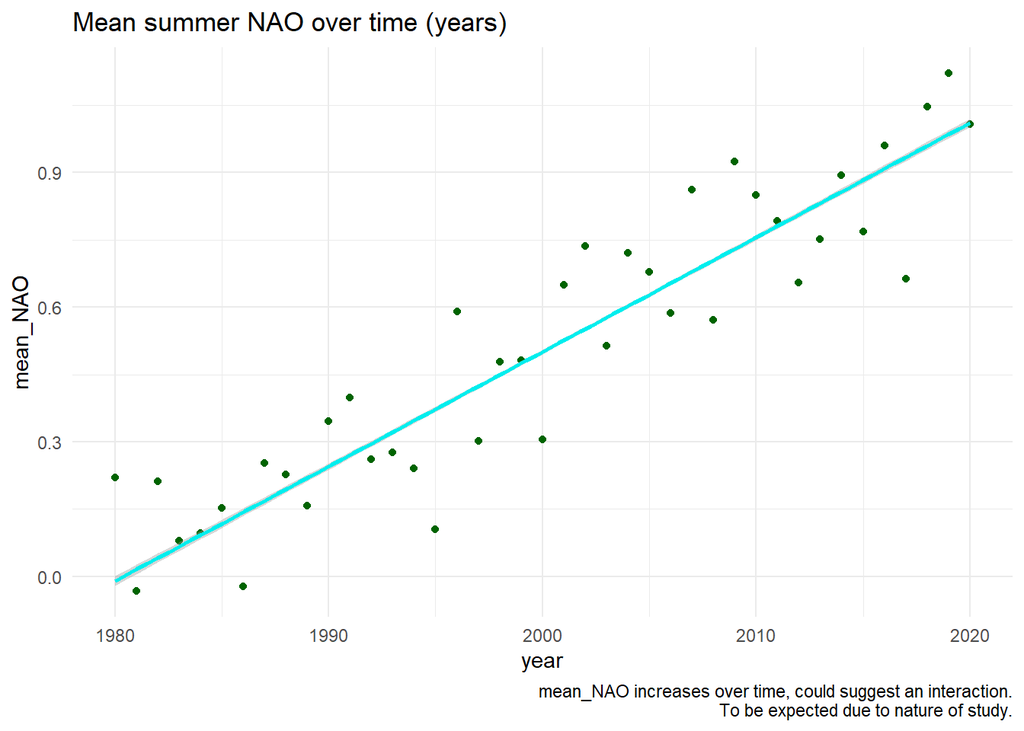

```r
#plot relationship between time and mean NAO
ggplot(mass_NAO_data, aes(x = year, y = mean_NAO)) +
  geom_point(col = "darkgreen") +
  geom_smooth(col = "cyan2", method = "lm") +
  labs(title = "Mean summer NAO over time (years)",
       caption = "mean_NAO increases over time, could suggest an interaction.
       To be expected due to nature of study.") +
  theme_minimal()
```

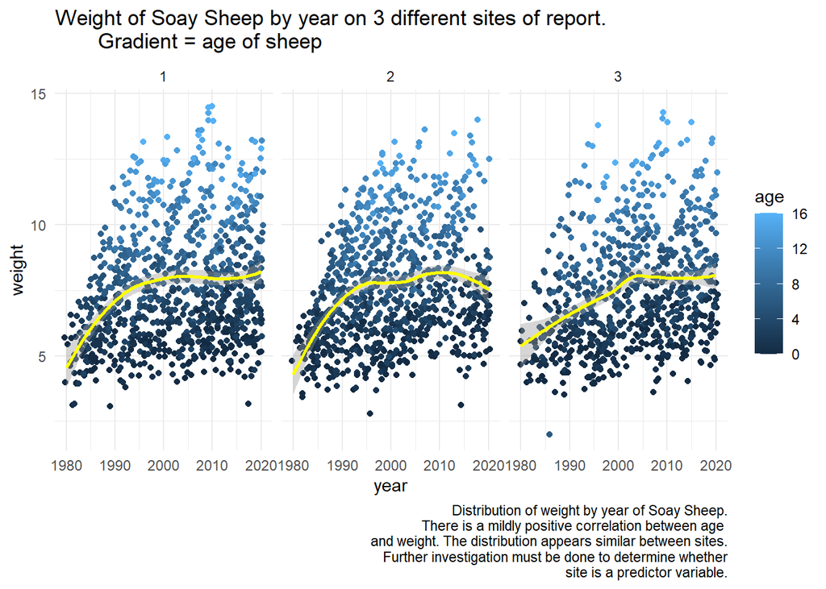

```r
ggplot(data = mass_data_NA, aes(x = year, y = weight)) +
  geom_jitter(aes(colour = age)) +
  geom_smooth(colour = "yellow") +
  facet_wrap(~site) + #graph for each site
  labs(title = "Weight of Soay Sheep by year on 3 different sites of report.
       Gradient = age of sheep",
       caption = "Distribution of weight by year of Soay Sheep.
      There is a mildly positive correlation between age
       and weight. The distribution appears similar between sites.
       Further investigation must be done to determine whether
       site is a predictor variable.") +
  theme_minimal() # outlier visible # the site of the sheep visually has little effect on weight by age
```

We must start fitting models to our data, given the response variable *`weight`*.

```r
newfit <- fitdist(mass_NAO_data$weight, "norm") #fit weight to a normal distribution
summary(newfit) #descriptive statistics
```

```
## Fitting of the distribution ' norm ' by maximum likelihood
## Parameters :
##      estimate Std. Error
## mean 7.541517 0.04319777
## sd   2.195875 0.03054541
## Loglikelihood:  -5699.061   AIC:  11402.12   BIC:  11413.84
## Correlation matrix:
##      mean sd
## mean    1  0
## sd      0  1
```

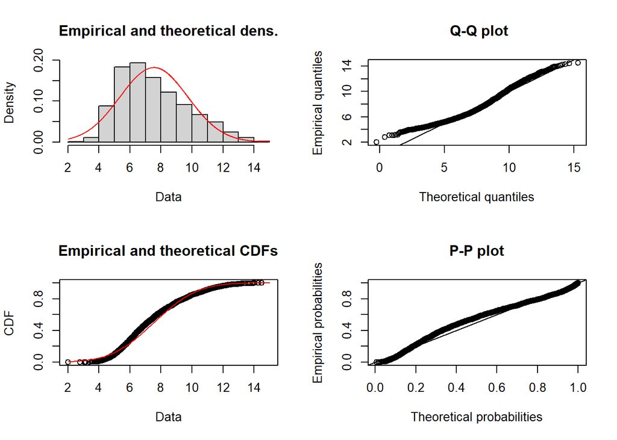

```r
plot(newfit) #visualise fit
```

```r
gofstat(newfit) #goodness of fit statistics
```

```
## Goodness-of-fit statistics
##                               1-mle-norm
## Kolmogorov-Smirnov statistic  0.07524494
## Cramer-von Mises statistic    4.85473923
## Anderson-Darling statistic   29.26824699
##
## Goodness-of-fit criteria
##                                1-mle-norm
## Akaike's Information Criterion   11402.12
## Bayesian Information Criterion   11413.84
```

The data is almost normally distributed, with a positive skew.

This is confirmed by histograms, per sex.

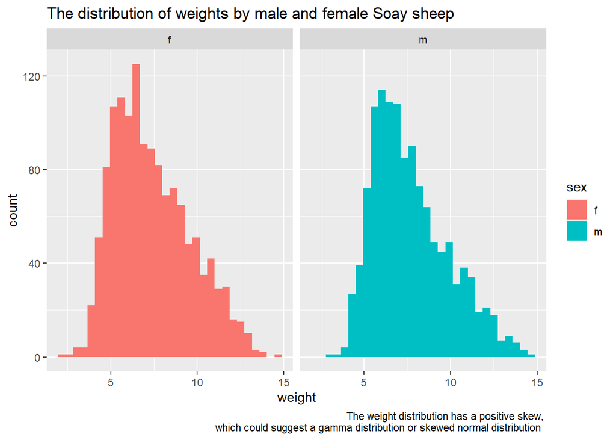

```r
#create histograms by sex
ggplot(mass_NAO_data, aes(x = weight)) +
  geom_histogram(aes(fill = sex)) +
  facet_wrap("sex") +

  labs(title = "The distribution of weights by male and female Soay sheep",
       caption = "The weight distribution has a positive skew,
       which could suggest a gamma distribution or skewed normal distribution  ")
```

## Checking distribution

#### Testing different distributions of GLM

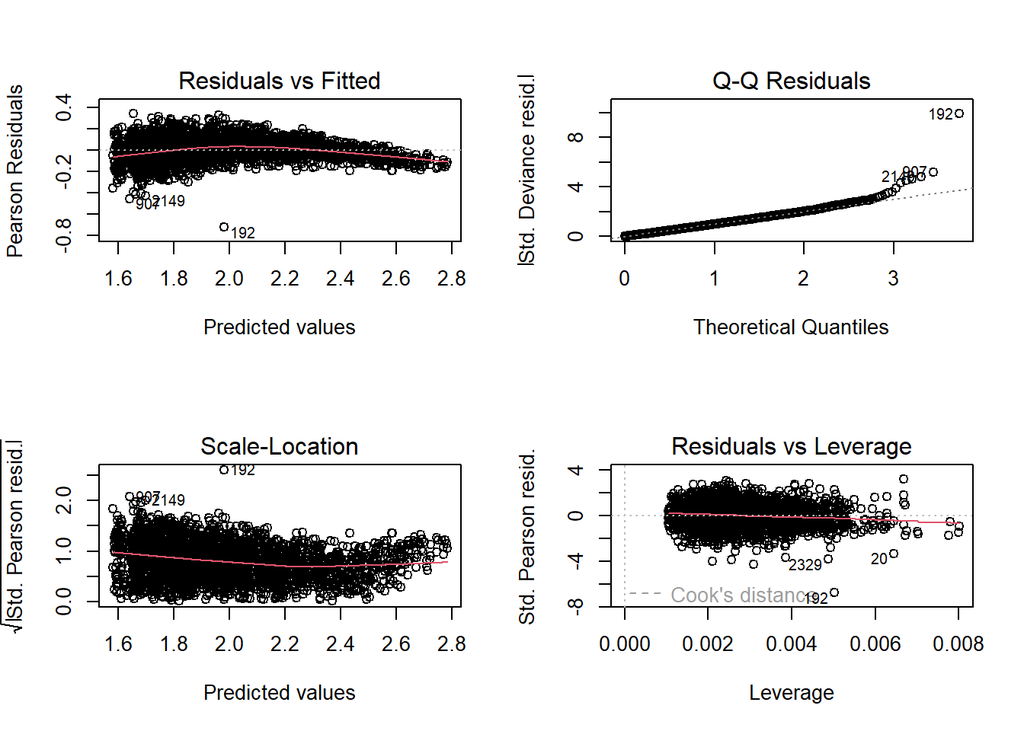

```r
mod_gamma <- glm(weight ~ age + sex + year + mean_NAO + site + year:mean_NAO, data = mass_NAO_data, family = Gamma(link = "log")) #gamma model with log link
par(mfrow = c(2,2))
plot(mod_gamma)
```

```r
summary(mod_gamma) #deescriptive statistsics of model
```

```
##
## Call:
## glm(formula = weight ~ age + sex + year + mean_NAO + site + year:mean_NAO,
##     family = Gamma(link = "log"), data = mass_NAO_data)
##
## Coefficients:
##                 Estimate Std. Error t value Pr(>|t|)
## (Intercept)   -0.9391489  1.2047737  -0.780   0.4357
## age            0.0642012  0.0005470 117.364   <2e-16 ***
## sexm           0.0621513  0.0042461  14.637   <2e-16 ***
## year           0.0012700  0.0006059   2.096   0.0362 *
## mean_NAO      -2.2456184  1.4782269  -1.519   0.1289
## site           0.0048741  0.0026160   1.863   0.0626 .
## year:mean_NAO  0.0011543  0.0007379   1.564   0.1178
## ---
## Signif. codes:  0 '***' 0.001 '**' 0.01 '*' 0.05 '.' 0.1 ' ' 1
##
## (Dispersion parameter for Gamma family taken to be 0.01154869)
##
##     Null deviance: 214.728  on 2583  degrees of freedom
## Residual deviance:  31.272  on 2577  degrees of freedom
## AIC: 6174.4
##
## Number of Fisher Scoring iterations: 4
```

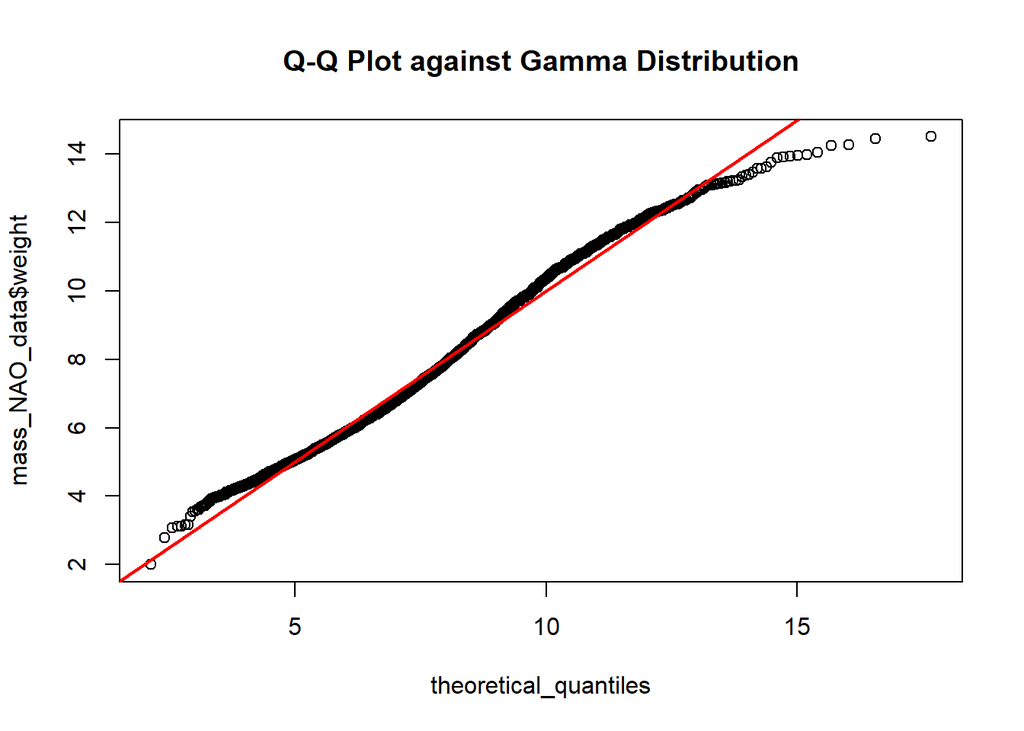

```r
#fit a gamma distribution
gammafit <- fitdist(mass_NAO_data$weight, "gamma")

#FIT ESTIMATES
shape <- gammafit$estimate["shape"]
rate <- gammafit$estimate["rate"]

#generate quantiles from the gamma distribution
theoretical_quantiles <- qgamma(ppoints(length(mass_NAO_data$weight)), shape = shape, rate = rate)

#create qqplot
qqplot(theoretical_quantiles, mass_NAO_data$weight, main = "Q-Q Plot against Gamma Distribution")
abline(0, 1, col = "red", lwd = 2)  #reference line
```

We can compare this to a normally fitted GLM.

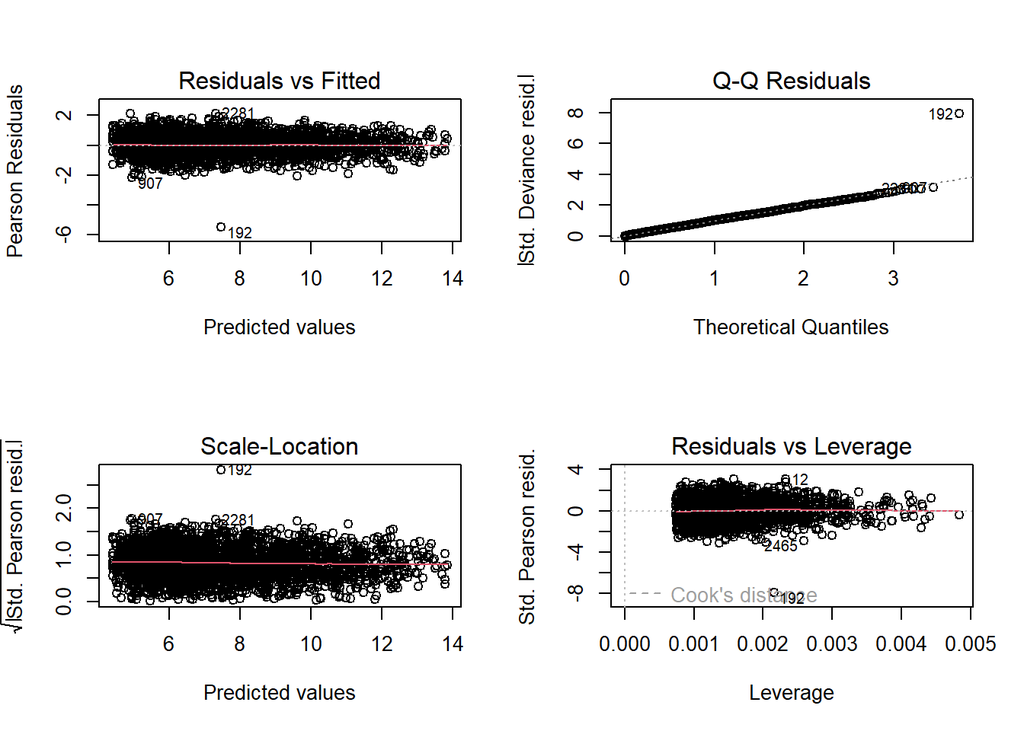

```r
mod_NAO <- glm(weight ~ age + sex + mean_NAO ,
                   ##specify the data
                   data = mass_NAO_data,
                   ##specify the error structure
                   family = "gaussian")

par(mfrow = c(2,2))
plot(mod_NAO)
```

```r
#Compare AIC values to determine best fit
AIC(mod_NAO) #lower AIC = better fit.
```

```
## [1] 5426.49
```

```r
AIC(mod_gamma)
```

```
## [1] 6174.394
```

## Outlier Removal

In the previous plots, an outlying point can be seen.

```r
summary(mod_NAO)
```

```
##
## Call:
## glm(formula = weight ~ age + sex + mean_NAO, family = "gaussian",
##     data = mass_NAO_data)
##
## Coefficients:
##             Estimate Std. Error t value Pr(>|t|)
## (Intercept) 4.431388   0.033465  132.42   <2e-16 ***
## age         0.510083   0.003443  148.14   <2e-16 ***
## sexm        0.447777   0.027278   16.41   <2e-16 ***
## mean_NAO    0.884276   0.045541   19.42   <2e-16 ***
## ---
## Signif. codes:  0 '***' 0.001 '**' 0.01 '*' 0.05 '.' 0.1 ' ' 1
##
## (Dispersion parameter for gaussian family taken to be 0.4770362)
##
##     Null deviance: 12459.7  on 2583  degrees of freedom
## Residual deviance:  1230.8  on 2580  degrees of freedom
## AIC: 5426.5
##
## Number of Fisher Scoring iterations: 2
```

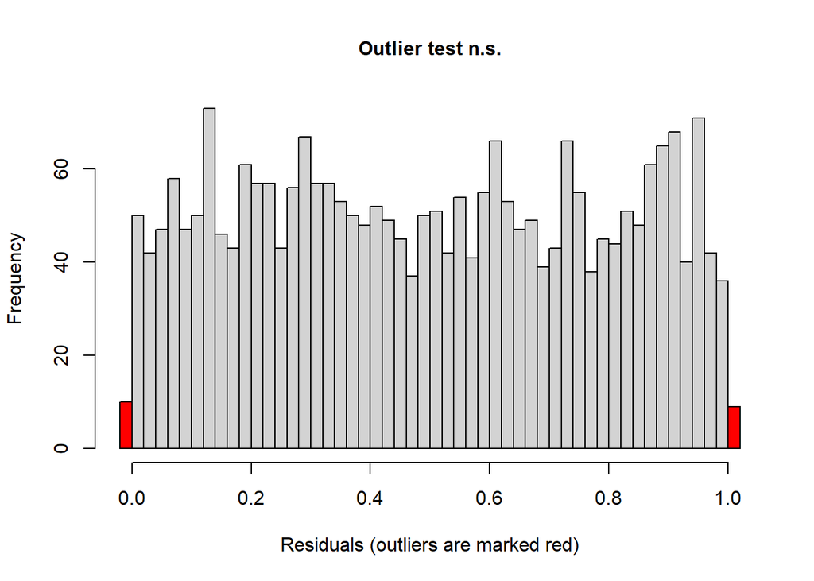

```
##
##  DHARMa outlier test based on exact binomial test with approximate
##  expectations
##
## data:  mod_NAO
## outliers at both margin(s) = 19, observations = 2584, p-value = 0.8249
## alternative hypothesis: true probability of success is not equal to 0.007968127
## 95 percent confidence interval:
##  0.004432587 0.011458811
## sample estimates:
## frequency of outliers (expected: 0.00796812749003984 )
##                                            0.007352941
```

```r
testOutliers(mod_NAO) #view data spread with outlying points
```

When we `check_model`, the outlier is also visible there.

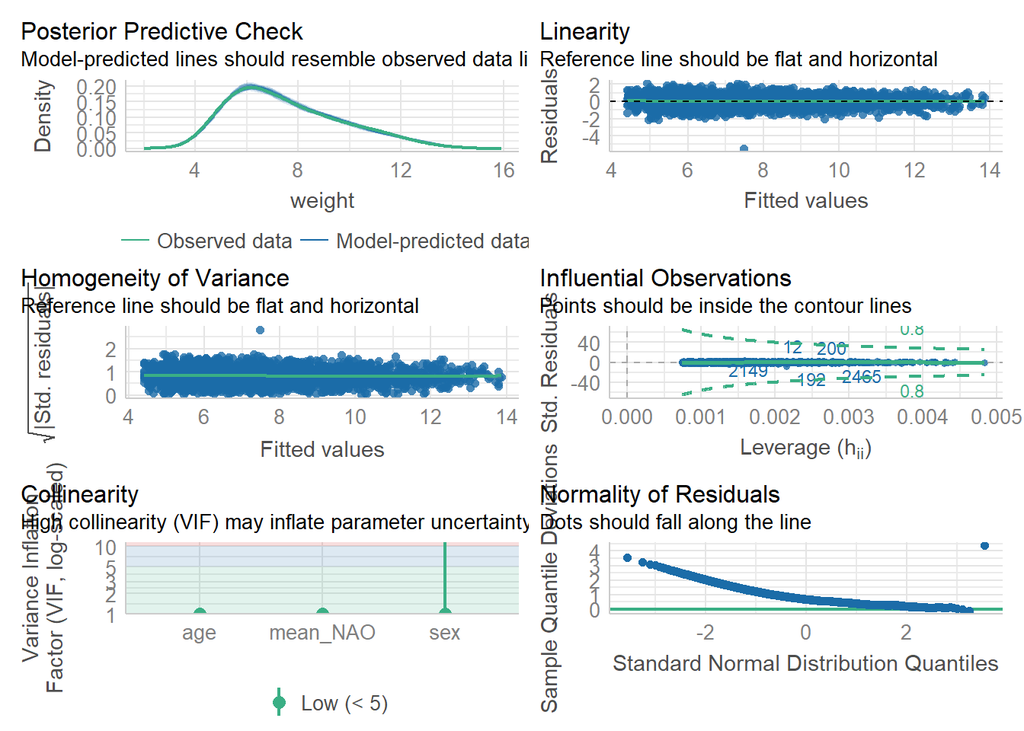

```r
check_model(mod_NAO)
```

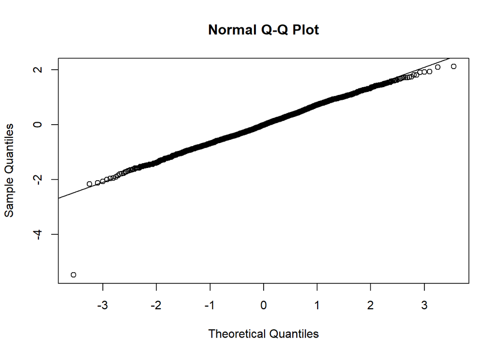

```r
residuals <- residuals(mod_NAO) #residuals of gaussian model

qqnorm(residuals) #visualise normality of residuals
qqline(residuals)
```

```r
#normality of residuals is far better for gaussian distribution model.
```

The outlier is found and removed from the data.

```r
outlier_indices <- which(abs(residuals) > mass_NAO_data$weight) #find outlying points
outlier_indices
```

```
## 192
## 192
```

```r
cleaned_data <- mass_NAO_data[-outlier_indices,]
```

This is the final dataset that we will be using to create models.

## Determining predictors and fitting a GLM

Next, we create a model with all variables with regards to weight, to determine which have a significant effect and are therefore predictor variables.

```r
predictormodel <- lm(weight ~ age +
                       ID +
                       sex +
                       n_babies +
                       site +
                       year +
                       pop_size +
                       mean_NAO +
                       year:mean_NAO,
                     data = cleaned_data) #include all variables
anova(predictormodel) #determine which variables have a statistically significant effect on weight and should be considered predictor variables
```

```
## Analysis of Variance Table
##
## Response: weight
##                 Df  Sum Sq Mean Sq    F value    Pr(>F)
## age              1 10910.5 10910.5 23690.3701 < 2.2e-16 ***
## ID               1     1.3     1.3     2.8030   0.09421 .
## sex              1   142.3   142.3   308.8909 < 2.2e-16 ***
## n_babies         1     0.1     0.1     0.1283   0.72027
## site             1     2.1     2.1     4.4702   0.03459 *
## year             1   169.4   169.4   367.7895 < 2.2e-16 ***
## pop_size         1     0.8     0.8     1.7443   0.18671
## mean_NAO         1    12.3    12.3    26.7181 2.535e-07 ***
## year:mean_NAO    1     5.3     5.3    11.5440   0.00069 ***
## Residuals     2573  1185.0     0.5
## ---
## Signif. codes:  0 '***' 0.001 '**' 0.01 '*' 0.05 '.' 0.1 ' ' 1
```

```r
#asterisks and p-values determine which variables have significant effect
```

As site is only marginally significant, we must determine whether it should be a predictor variable or not. The significance of age, sex, year:mean_NAO, mean_NAO and year suggest they should be in our model.

```r
glm_w_site <- glm(weight ~ age
                  + sex
                  + year
                  + mean_NAO
                  + site
                  + year:mean_NAO,
                  data = cleaned_data)
summary(glm_w_site)
```

```
##
## Call:
## glm(formula = weight ~ age + sex + year + mean_NAO + site + year:mean_NAO,
##     data = cleaned_data)
##
## Coefficients:
##                 Estimate Std. Error t value Pr(>|t|)
## (Intercept)     1.504851   7.609352   0.198 0.843246
## age             0.512354   0.003455 148.295  < 2e-16 ***
## sexm            0.445383   0.026816  16.609  < 2e-16 ***
## year            0.001499   0.003827   0.392 0.695263
## mean_NAO      -34.941913   9.344416  -3.739 0.000189 ***
## site            0.037969   0.016526   2.297 0.021671 *
## year:mean_NAO   0.017707   0.004664   3.796 0.000150 ***
## ---
## Signif. codes:  0 '***' 0.001 '**' 0.01 '*' 0.05 '.' 0.1 ' ' 1
##
## (Dispersion parameter for gaussian family taken to be 0.4605169)
##
##     Null deviance: 12429.0  on 2582  degrees of freedom
## Residual deviance:  1186.3  on 2576  degrees of freedom
## AIC: 5336.4
##
## Number of Fisher Scoring iterations: 2
```

```r
glm_wo_site <- glm(weight ~ age
                   + sex
                   + year
                   + mean_NAO
                   + year:mean_NAO,
                   data = cleaned_data)
summary(glm_wo_site)
```

```
##
## Call:
## glm(formula = weight ~ age + sex + year + mean_NAO + year:mean_NAO,
##     data = cleaned_data)
##
## Coefficients:
##                 Estimate Std. Error t value Pr(>|t|)
## (Intercept)     1.148936   7.614088   0.151 0.880070
## age             0.511942   0.003453 148.253  < 2e-16 ***
## sexm            0.445377   0.026838  16.595  < 2e-16 ***
## year            0.001715   0.003829   0.448 0.654245
## mean_NAO      -33.973002   9.342641  -3.636 0.000282 ***
## year:mean_NAO   0.017224   0.004663   3.693 0.000226 ***
## ---
## Signif. codes:  0 '***' 0.001 '**' 0.01 '*' 0.05 '.' 0.1 ' ' 1
##
## (Dispersion parameter for gaussian family taken to be 0.4612815)
##
##     Null deviance: 12429.0  on 2582  degrees of freedom
## Residual deviance:  1188.7  on 2577  degrees of freedom
## AIC: 5339.6
##
## Number of Fisher Scoring iterations: 2
```

```r
AIC(glm_w_site)
```

```
## [1] 5336.354
```

```r
AIC(glm_wo_site)
```

```
## [1] 5339.642
```

Our GLM with site is marginally better as shown by the AIC value.

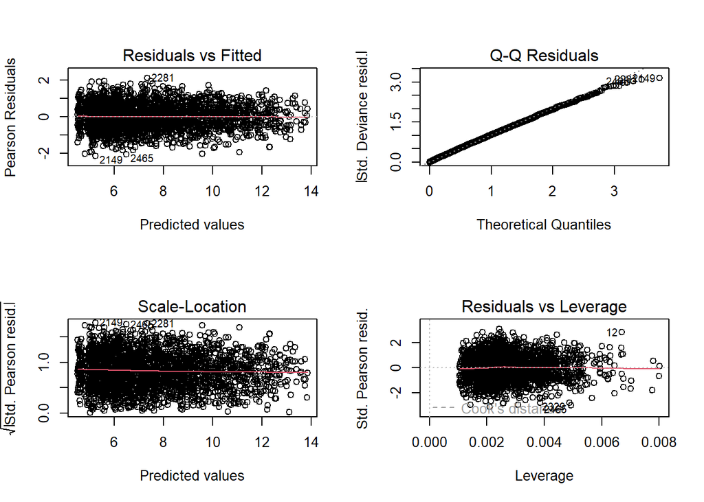

```r
cleaned_model <- glm(weight ~ age + sex + mean_NAO + year + site + year:mean_NAO,
                     data = cleaned_data)
par (mfrow = c(2,2))
plot(cleaned_model)
```

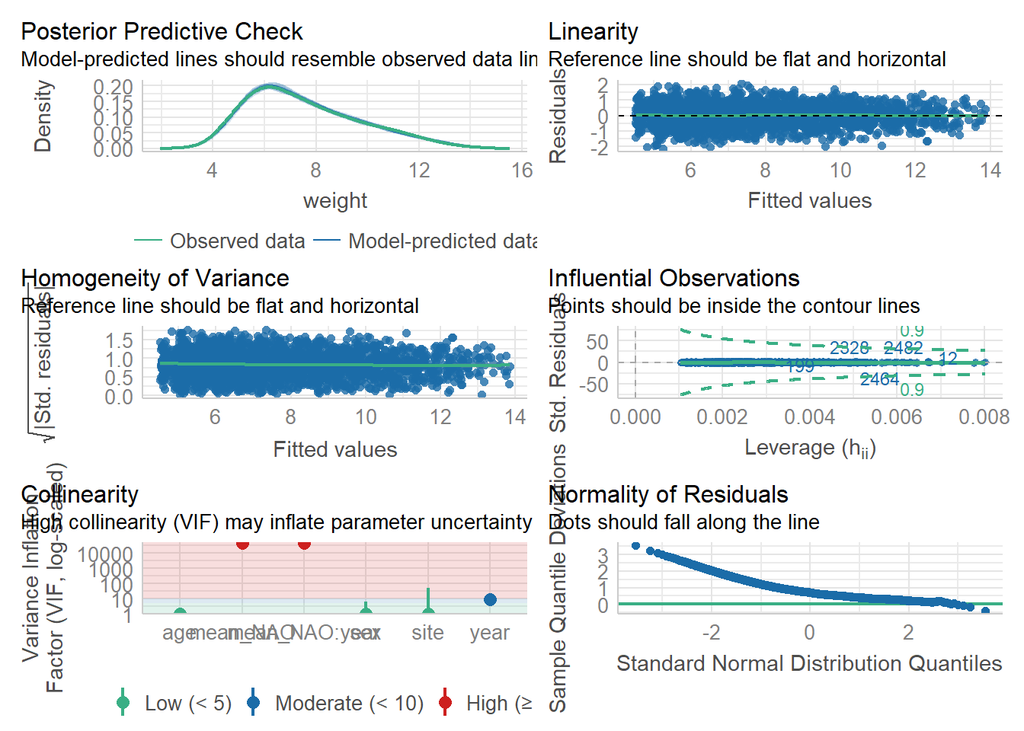

```r
check_model(cleaned_model)
```

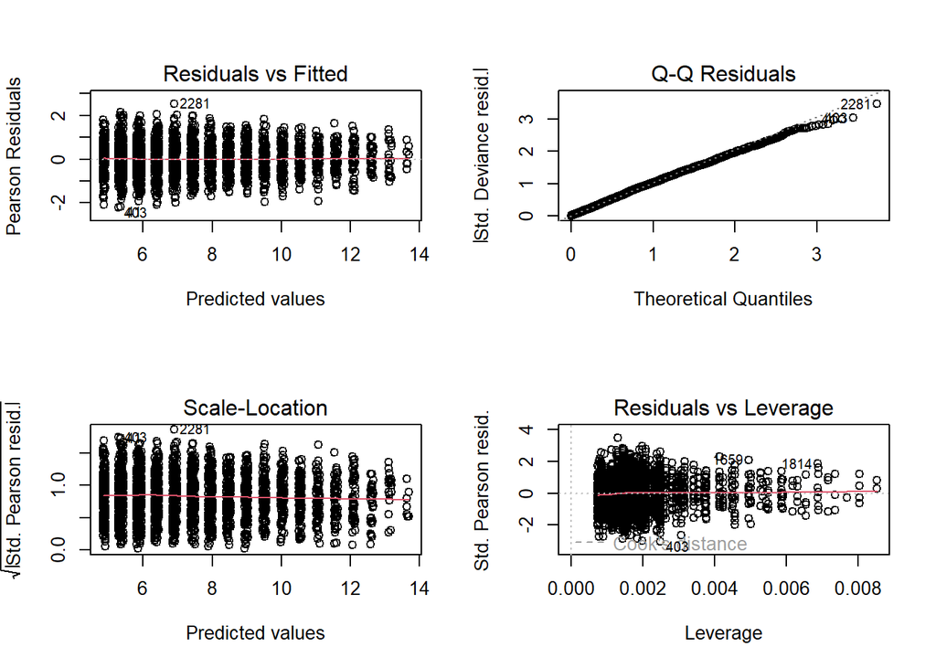

```r
cleaned_model2 <- glm(weight ~ age + sex + site + age:sex,
                      data = cleaned_data)
plot(cleaned_model2)
```

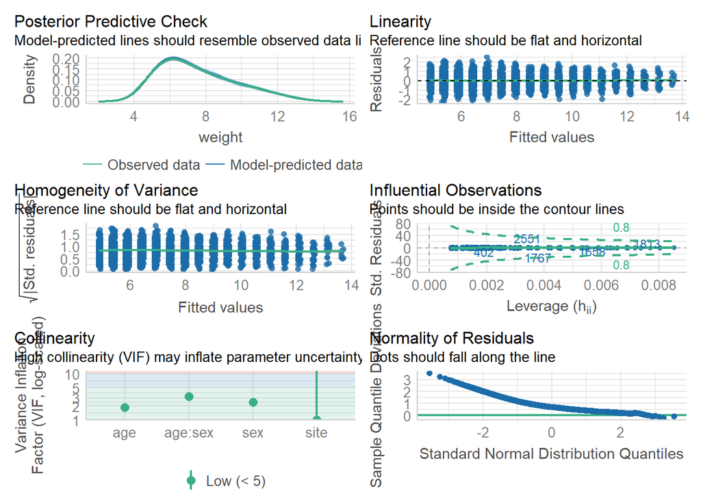

```r
check_model(cleaned_model2)
```

We should compare this data to a gamma distributed GLM, as our histogram was right-skewed.

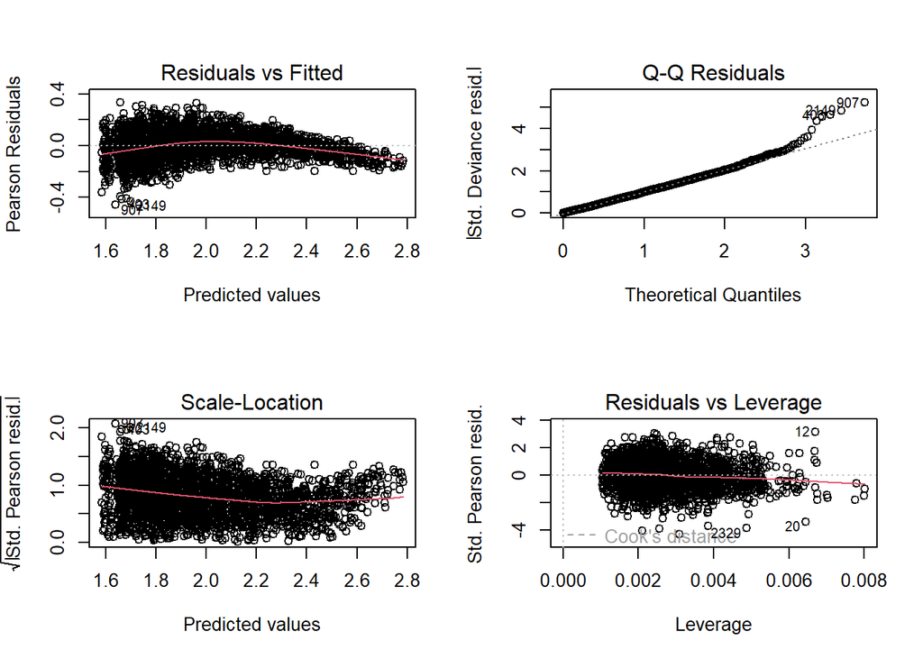

```r
gamma_model <- glm(weight ~ age
                   + sex
                   + mean_NAO
                   + year
                   + site
                   + year:mean_NAO,
                     data = cleaned_data,
                   family = Gamma(link ="log"))
par(mfrow = c(2,2))
plot(gamma_model)
```

```r
lrtest(gamma_model,cleaned_model) #H0: both models fit the data as well as each other
```

```
## Likelihood ratio test
##
## Model 1: weight ~ age + sex + mean_NAO + year + site + year:mean_NAO
## Model 2: weight ~ age + sex + mean_NAO + year + site + year:mean_NAO
##   #Df  LogLik Df  Chisq Pr(>Chisq)
## 1   8 -3032.1
## 2   8 -2660.2  0 743.88  < 2.2e-16 ***
## ---
## Signif. codes:  0 '***' 0.001 '**' 0.01 '*' 0.05 '.' 0.1 ' ' 1
```

```r
AIC(cleaned_model)
```

```
## [1] 5336.354
```

```r
AIC(cleaned_model2)
```

```
## [1] 5709.373
```

Comparing the gamma and Gaussian distributed GLMs, the Gaussian residuals have a far better distribution, QQ plot and lower AIC value. The p-value given by our likelihood-ratio test determines that our gaussian distribution fits significantly better than our gamma distribution.

## Creating and testing GLMMs

```r
testGLMM <- glmmTMB(weight ~ age +
                      sex +
                      site +
                      age:sex +
                      mean_NAO +
                      (1|ID) +
                      (1|pop_size),
                    data = cleaned_data, family = "gaussian")
summary(testGLMM)
```

```
##  Family: gaussian  ( identity )
## Formula:
## weight ~ age + sex + site + age:sex + mean_NAO + (1 | ID) + (1 |      pop_size)
## Data: cleaned_data
##
##      AIC      BIC   logLik deviance df.resid
##   2031.9   2084.6  -1006.9   2013.9     2574
##
## Random effects:
##
## Conditional model:
##  Groups   Name        Variance Std.Dev.
##  ID       (Intercept) 0.39256  0.6265
##  pop_size (Intercept) 0.03221  0.1795
##  Residual             0.07490  0.2737
## Number of obs: 2583, groups:  ID, 387; pop_size, 27
##
## Dispersion estimate for gaussian family (sigma^2): 0.0749
##
## Conditional model:
##              Estimate Std. Error z value Pr(>|z|)
## (Intercept) 4.3322716  0.1036723   41.79  < 2e-16 ***
## age         0.5097024  0.0026892  189.54  < 2e-16 ***
## sexm        0.4225498  0.0662613    6.38 1.81e-10 ***
## site        0.0310024  0.0399718    0.78    0.438
## mean_NAO    0.9660981  0.0638718   15.13  < 2e-16 ***
## age:sexm    0.0005773  0.0033343    0.17    0.863
## ---
## Signif. codes:  0 '***' 0.001 '**' 0.01 '*' 0.05 '.' 0.1 ' ' 1
```

```r
#GLMM with only ID as random effect
glmm_model_ID <- glmmTMB(weight ~ age +
                           sex +
                           year +
                           mean_NAO +
                           site +
                           year:mean_NAO +
                           (1|ID),
                         data = cleaned_data, family = "gaussian")
summary(glmm_model_ID)
```

```
##  Family: gaussian  ( identity )
## Formula:
## weight ~ age + sex + year + mean_NAO + site + year:mean_NAO +      (1 | ID)
## Data: cleaned_data
##
##      AIC      BIC   logLik deviance df.resid
##   2479.8   2532.5  -1230.9   2461.8     2574
##
## Random effects:
##
## Conditional model:
##  Groups   Name        Variance Std.Dev.
##  ID       (Intercept) 0.37858  0.6153
##  Residual             0.09602  0.3099
## Number of obs: 2583, groups:  ID, 387
##
## Dispersion estimate for gaussian family (sigma^2): 0.096
##
## Conditional model:
##                 Estimate Std. Error z value Pr(>|z|)
## (Intercept)    -6.270256   6.956031   -0.90  0.36737
## age             0.506331   0.003219  157.27  < 2e-16 ***
## sexm            0.433694   0.064771    6.70 2.14e-11 ***
## year            0.005402   0.003485    1.55  0.12114
## mean_NAO      -18.702904   6.340493   -2.95  0.00318 **
## site            0.036972   0.039555    0.93  0.34995
## year:mean_NAO   0.009601   0.003165    3.03  0.00242 **
## ---
## Signif. codes:  0 '***' 0.001 '**' 0.01 '*' 0.05 '.' 0.1 ' ' 1
```

```r
muminID <- r.squaredGLMM((glmm_model_ID)) #calculate R2m and R2c values
muminID
```

```
##            R2m       R2c
## [1,] 0.8999356 0.9797558
```

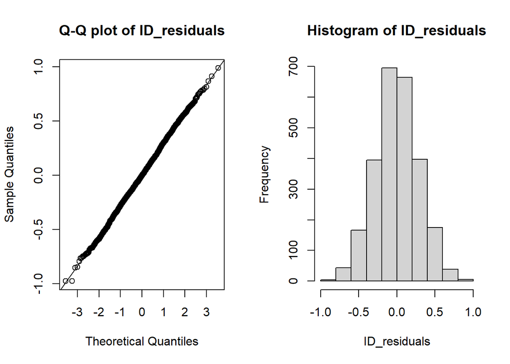

```r
ID_residuals <- residuals(glmm_model_ID)
par(mfrow = c(1,2)) #view subplots together
qqnorm(ID_residuals, main = "Q-Q plot of ID_residuals") #create QQ plot of the residuals of this model
qqline(ID_residuals)
hist(ID_residuals)
```

```r
#GLMM with pop_size as random effect
glmm_model_pop <- glmmTMB(weight ~ age +
                            sex +
                            mean_NAO +
                            site +
                            year +
                            year:mean_NAO +
                            (1 | pop_size),
                    data = cleaned_data,
                    )
summary(glmm_model_pop)
```

```
##  Family: gaussian  ( identity )
## Formula:
## weight ~ age + sex + mean_NAO + site + year + year:mean_NAO +
##     (1 | pop_size)
## Data: cleaned_data
##
##      AIC      BIC   logLik deviance df.resid
##   5287.5   5340.2  -2634.7   5269.5     2574
##
## Random effects:
##
## Conditional model:
##  Groups   Name        Variance Std.Dev.
##  pop_size (Intercept) 0.02459  0.1568
##  Residual             0.44224  0.6650
## Number of obs: 2583, groups:  pop_size, 27
##
## Dispersion estimate for gaussian family (sigma^2): 0.442
##
## Conditional model:
##                 Estimate Std. Error z value Pr(>|z|)
## (Intercept)    19.710029  10.324416    1.91   0.0563 .
## age             0.512739   0.003400  150.81  < 2e-16 ***
## sexm            0.443099   0.026324   16.83  < 2e-16 ***
## mean_NAO      -64.376360  14.590175   -4.41 1.02e-05 ***
## site            0.038610   0.016213    2.38   0.0172 *
## year           -0.007670   0.005192   -1.48   0.1396
## mean_NAO:year   0.032505   0.007275    4.47 7.91e-06 ***
## ---
## Signif. codes:  0 '***' 0.001 '**' 0.01 '*' 0.05 '.' 0.1 ' ' 1
```

```r
muminpop <- r.squaredGLMM(glmm_model_pop)
muminpop
```

```
##            R2m       R2c
## [1,] 0.9037254 0.9087974
```

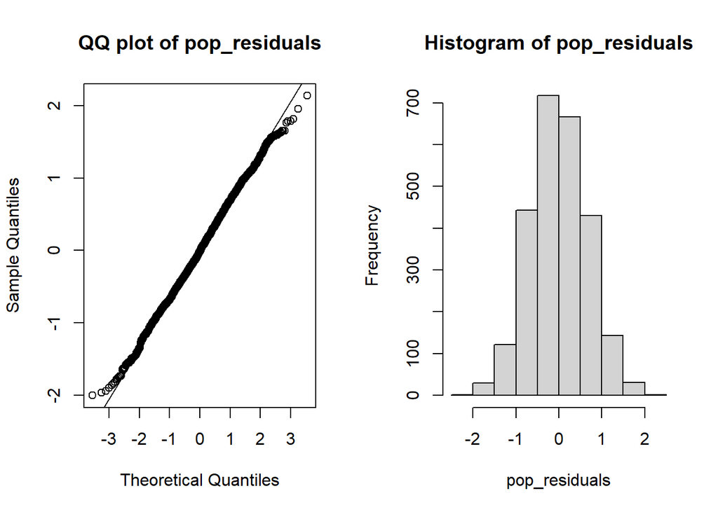

```r
pop_residuals <- residuals(glmm_model_pop)
par(mfrow = c(1,2))
qqnorm(pop_residuals, main = "QQ plot of pop_residuals")
qqline(pop_residuals)
hist(pop_residuals)
```

```r
#GLMM with ID and pop_size as random effects
ID_pop_model <- glmmTMB(weight ~
                          age +
                          sex +
                          site +
                          year +
                          mean_NAO +
                          year:mean_NAO +
                          (1|ID) +
                          (1|pop_size),
                        data = cleaned_data, family = "gaussian")
#with site, the AIC drops so we should discount it from our model
muminbig <- r.squaredGLMM(ID_pop_model) #check R2m and R2c
muminbig
```

```
##            R2m      R2c
## [1,] 0.8977047 0.984622
```

```r
summary(ID_pop_model)
```

```
##  Family: gaussian  ( identity )
## Formula:
## weight ~ age + sex + site + year + mean_NAO + year:mean_NAO +
##     (1 | ID) + (1 | pop_size)
## Data: cleaned_data
##
##      AIC      BIC   logLik deviance df.resid
##   2001.1   2059.6   -990.5   1981.1     2573
##
## Random effects:
##
## Conditional model:
##  Groups   Name        Variance Std.Dev.
##  ID       (Intercept) 0.38530  0.6207
##  pop_size (Intercept) 0.03294  0.1815
##  Residual             0.07400  0.2720
## Number of obs: 2583, groups:  ID, 387; pop_size, 27
##
## Dispersion estimate for gaussian family (sigma^2): 0.074
##
## Conditional model:
##                 Estimate Std. Error z value Pr(>|z|)
## (Intercept)    11.107882   7.729500    1.44    0.151
## age             0.506771   0.003118  162.55  < 2e-16 ***
## sexm            0.422469   0.064864    6.51 7.36e-11 ***
## site            0.032622   0.039608    0.82    0.410
## year           -0.003369   0.003875   -0.87    0.385
## mean_NAO      -46.185215   8.776024   -5.26 1.42e-07 ***
## year:mean_NAO   0.023460   0.004374    5.36 8.17e-08 ***
## ---
## Signif. codes:  0 '***' 0.001 '**' 0.01 '*' 0.05 '.' 0.1 ' ' 1
```

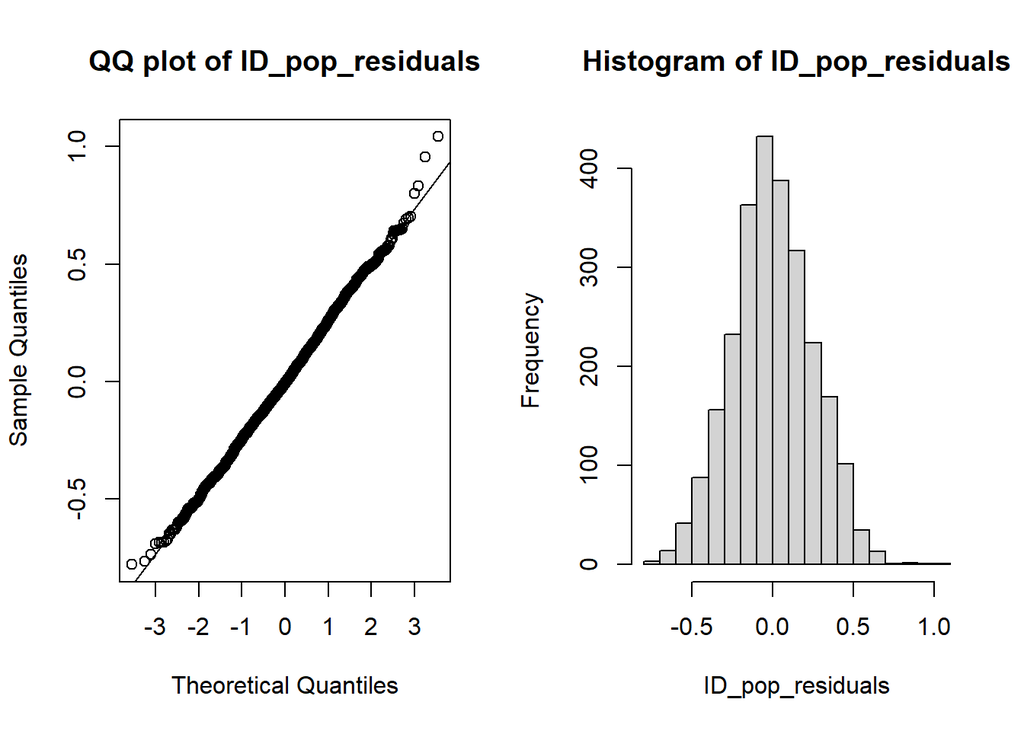

```r
ID_pop_residuals <- residuals(ID_pop_model)
par(mfrow = c(1,2))
qqnorm(ID_pop_residuals, main = "QQ plot of ID_pop_residuals")
qqline(ID_pop_residuals)
hist(ID_pop_residuals)
```

With both ID and pop_size as random effects, our AIC and BIC values decrease sizeably.

```r
#GLMM with both ID and pop size as random effects, dropping size as a predictor to see the effect
ID_pop_nosite <- glmmTMB(weight ~
                          age +
                          sex +
                          year +
                          mean_NAO +
                          year:mean_NAO +
                          (1|ID) +
                          (1|pop_size),
                        data = cleaned_data, family = "gaussian")
#with site, the AIC drops so we should discount it from our model
muminbig <- r.squaredGLMM(ID_pop_nosite) #check R2m and R2c
muminbig
```

```
##            R2m       R2c
## [1,] 0.8976485 0.9846377
```

```r
summary(ID_pop_nosite)
```

```
##  Family: gaussian  ( identity )
## Formula:
## weight ~ age + sex + year + mean_NAO + year:mean_NAO + (1 | ID) +
##     (1 | pop_size)
## Data: cleaned_data
##
##      AIC      BIC   logLik deviance df.resid
##   1999.8   2052.5   -990.9   1981.8     2574
##
## Random effects:
##
## Conditional model:
##  Groups   Name        Variance Std.Dev.
##  ID       (Intercept) 0.38607  0.6213
##  pop_size (Intercept) 0.03294  0.1815
##  Residual             0.07400  0.2720
## Number of obs: 2583, groups:  ID, 387; pop_size, 27
##
## Dispersion estimate for gaussian family (sigma^2): 0.074
##
## Conditional model:
##                 Estimate Std. Error z value Pr(>|z|)
## (Intercept)    11.149399   7.732910    1.44    0.149
## age             0.506757   0.003120  162.44  < 2e-16 ***
## sexm            0.422096   0.064924    6.50 7.96e-11 ***
## year           -0.003357   0.003877   -0.87    0.387
## mean_NAO      -46.126194   8.775781   -5.26 1.47e-07 ***
## year:mean_NAO   0.023431   0.004374    5.36 8.48e-08 ***
## ---
## Signif. codes:  0 '***' 0.001 '**' 0.01 '*' 0.05 '.' 0.1 ' ' 1
```

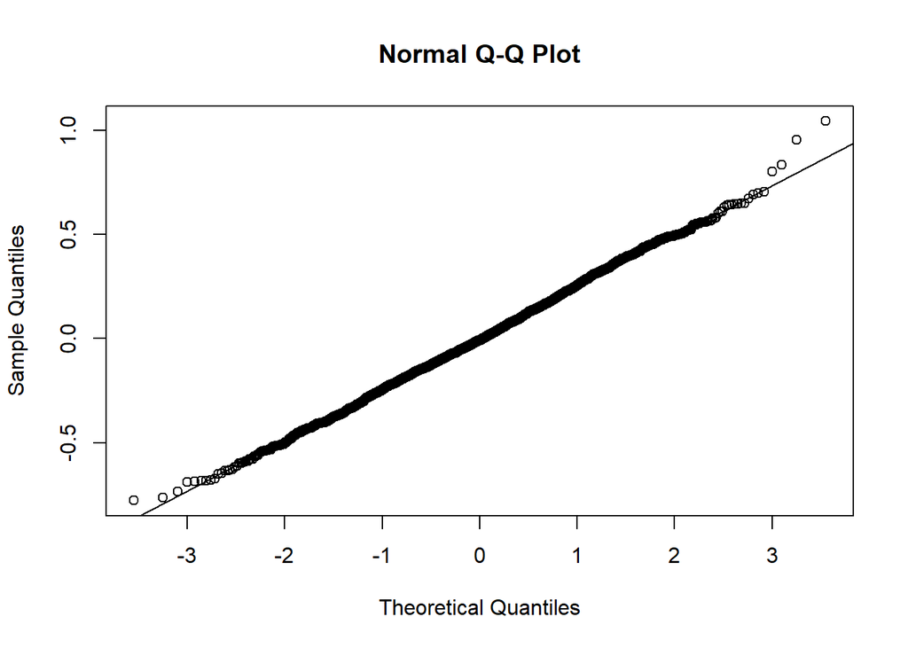

```r
ID_pop_nosite_residuals <- residuals(ID_pop_nosite)
qqnorm(ID_pop_nosite_residuals)
qqline(ID_pop_nosite_residuals)
```

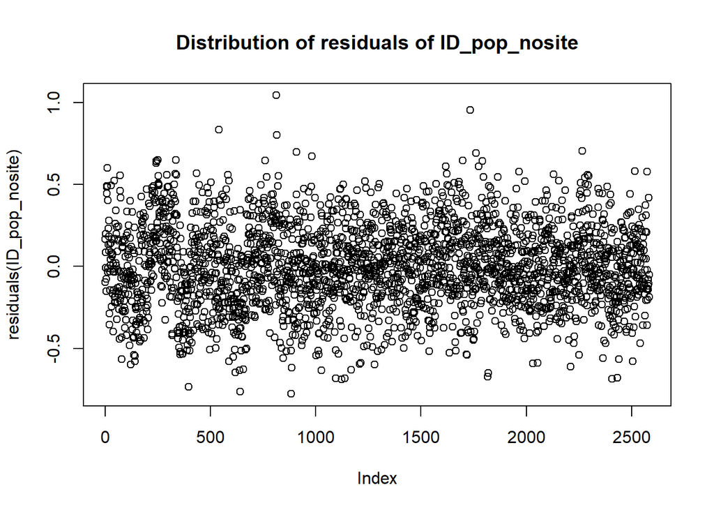

```r
plot(residuals(ID_pop_nosite), main = "Distribution of residuals of ID_pop_nosite")
```

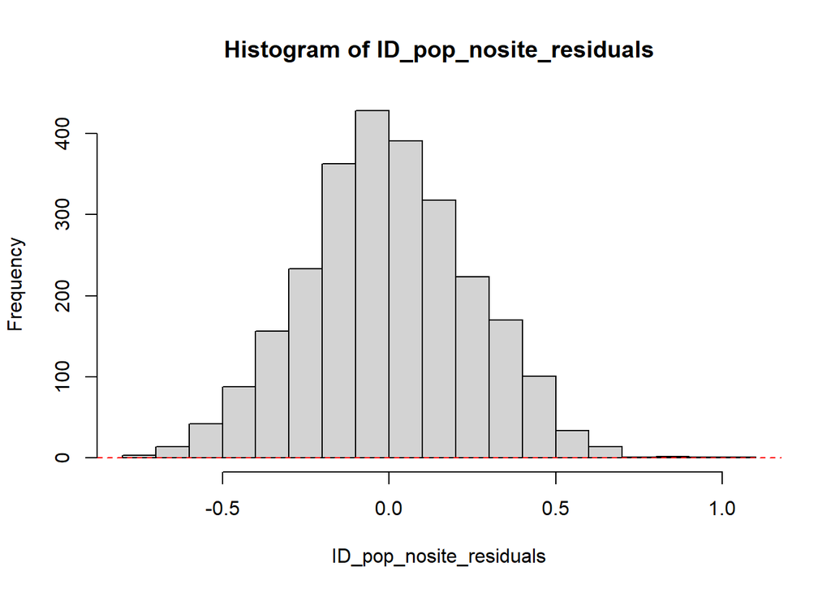

```r
hist(ID_pop_nosite_residuals)
abline(h = 0, col = "red", lty = 2)
```

We can run an ANOVA with all these models to determine which is the best fit.

```r
glmm_test <- anova(ID_pop_model, glmm_model_pop, glmm_model_ID)
glmm_test
```

```
## Data: cleaned_data
## Models:
## glmm_model_pop: weight ~ age + sex + mean_NAO + site + year + year:mean_NAO + , zi=~0, disp=~1
## glmm_model_pop:     (1 | pop_size), zi=~0, disp=~1
## glmm_model_ID: weight ~ age + sex + year + mean_NAO + site + year:mean_NAO + , zi=~0, disp=~1
## glmm_model_ID:     (1 | ID), zi=~0, disp=~1
## ID_pop_model: weight ~ age + sex + site + year + mean_NAO + year:mean_NAO + , zi=~0, disp=~1
## ID_pop_model:     (1 | ID) + (1 | pop_size), zi=~0, disp=~1
##                Df    AIC    BIC   logLik deviance   Chisq Chi Df Pr(>Chisq)
## glmm_model_pop  9 5287.5 5340.2 -2634.75   5269.5
## glmm_model_ID   9 2479.8 2532.5 -1230.91   2461.8 2807.67      0  < 2.2e-16 ***
## ID_pop_model   10 2001.1 2059.6  -990.54   1981.1  480.74      1  < 2.2e-16 ***
## ---
## Signif. codes:  0 '***' 0.001 '**' 0.01 '*' 0.05 '.' 0.1 ' ' 1
```

```r
pairwise<- lrtest(ID_pop_model, ID_pop_nosite)
pairwise #compare the two best models
```

```
## Likelihood ratio test
##
## Model 1: weight ~ age + sex + site + year + mean_NAO + year:mean_NAO +
##     (1 | ID) + (1 | pop_size)
## Model 2: weight ~ age + sex + year + mean_NAO + year:mean_NAO + (1 | ID) +
##     (1 | pop_size)
##   #Df  LogLik Df  Chisq Pr(>Chisq)
## 1  10 -990.54
## 2   9 -990.88 -1 0.6777     0.4104
```

```r
par(mfrow=c(1,2), mar = c(4, 3, 4, 2.2) -1)
testDispersion(ID_pop_model)
```

```
##
##  DHARMa nonparametric dispersion test via sd of residuals fitted vs.
##  simulated
##
## data:  simulationOutput
## dispersion = 0.94149, p-value = 0.408
## alternative hypothesis: two.sided
```

```r
testDispersion(ID_pop_nosite)
```

```
##
##  DHARMa nonparametric dispersion test via sd of residuals fitted vs.
##  simulated
##
## data:  simulationOutput
## dispersion = 0.94189, p-value = 0.408
## alternative hypothesis: two.sided
```

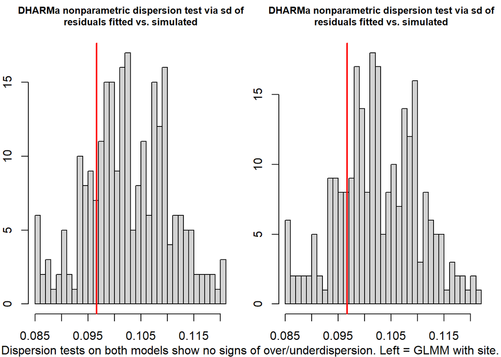

```r
mtext("Dispersion tests on both models show no signs of over/underdispersion. Left = GLMM with site.", side = 1, line = -1, outer = TRUE)
```

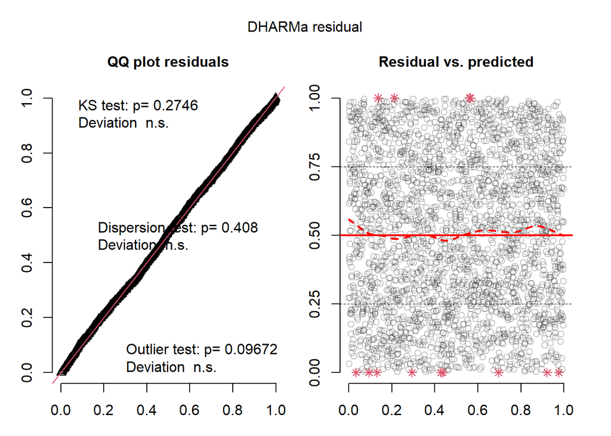

```r
plot(simulateResiduals(ID_pop_model))
```

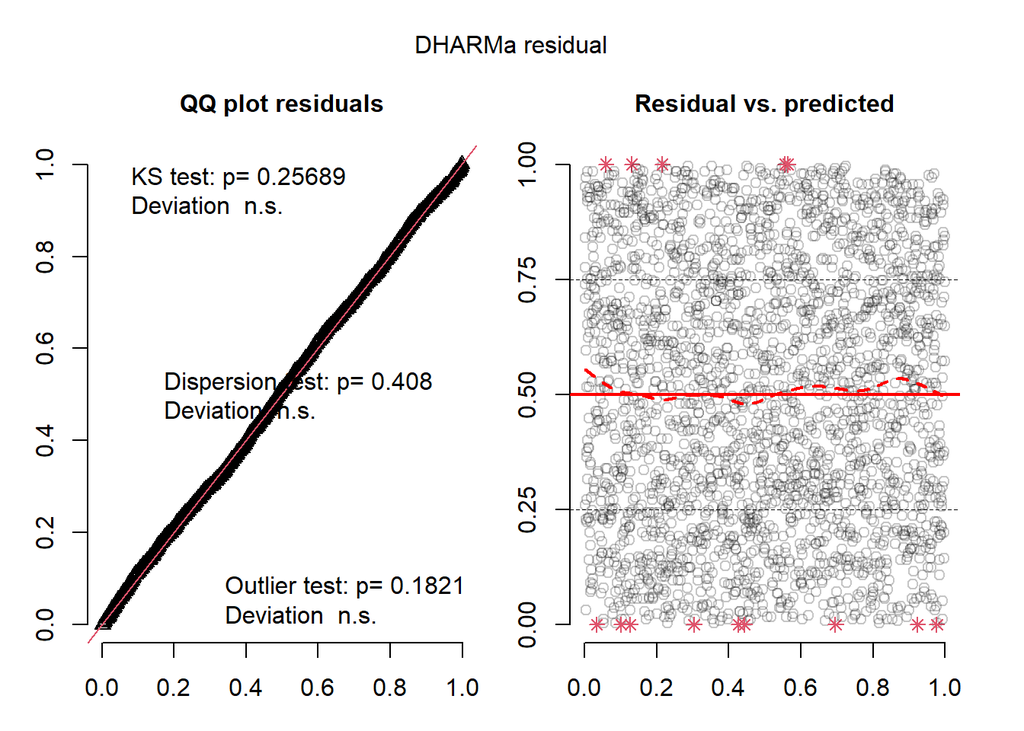

```r
plot(simulateResiduals(ID_pop_nosite))
```

The two best models I have fitted are not statistically significant from each other. As site does not effect the fit of the model, for simplicity of the model we may not include site as a predictor.

If the values predicted by the model are similar to that observed by the data, we can assume our model is a good fit.

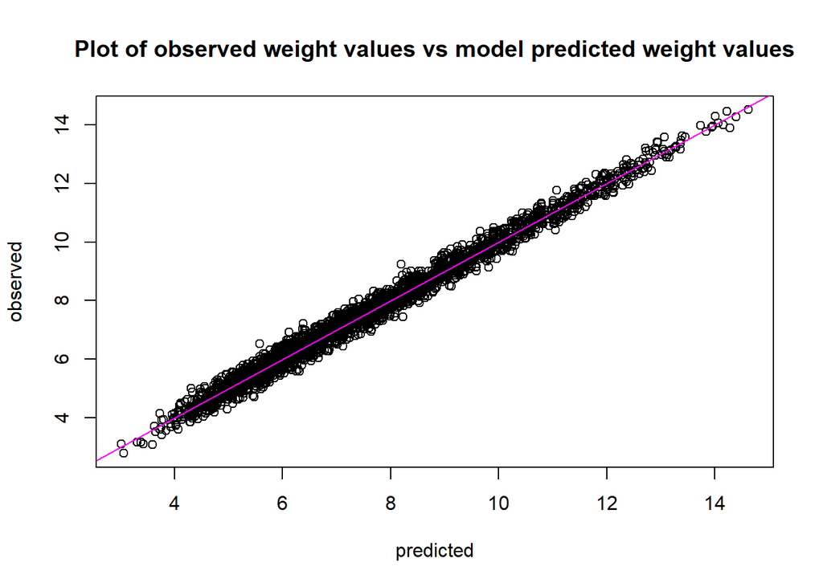

```r
predicted_values <- predict(ID_pop_nosite, type = "response") #create prediction

#add predicted and observed data into a separate dataframe
fit_data <- data.frame("predicted" = predicted_values,
                       "observed" = cleaned_data$weight)
plot(fit_data, main = "Plot of observed weight values vs model predicted weight values")
abline(0,1, col = "magenta")
```

Our data fits strongly against the x=y line, suggesting our model is emulating the values well.

```r
confints <- confint(ID_pop_nosite) #create confindence intervals as broom wouldn't do it for me
confints
```

```
##                                     2.5 %        97.5 %    Estimate
## (Intercept)                   -4.00682549  26.305624431  11.1493995
## age                            0.50064248   0.512871652   0.5067571
## sexm                           0.29484692   0.549344346   0.4220956
## year                          -0.01095479   0.004240989  -0.0033569
## mean_NAO                     -63.32640952 -28.925979182 -46.1261944
## year:mean_NAO                  0.01485751   0.032003689   0.0234306
## Std.Dev.(Intercept)|ID         0.57697774   0.669119454   0.6213429
## Std.Dev.(Intercept)|pop_size   0.13662049   0.241118326   0.1814985
```

```r
#turn into a dataframe so i can merge with the tidy model
confints_data <- data.frame(
  term = c("(Intercept)", "age", "sexm", "year", "mean_NAO", "year:mean_NAO", "Std.Dev.(Intercept)|ID", "Std.Dev.(Intercept)|pop_size"),
  conf_low = c(-4.00682549, 0.50064248, 0.29484692, -0.01095479, -63.32640952, 0.01485751, 0.57697774, 0.13662049),
  conf_high = c(26.305624431, 0.512871652, 0.549344346, 0.004240989, -28.925979182, 0.032003689, 0.669119454, 0.241118326),
  estimate = c(11.1493995, 0.5067571, 0.4220956, -0.0033569, -46.1261944, 0.0234306, 0.6213429, 0.1814985)
)

tidied_model <- broom.mixed::tidy(ID_pop_nosite, conf.int = FALSE) %>%
  mutate(term = ifelse(grepl("sd__(Int", term, fixed = TRUE),
                       paste(group, term, sep = "."),
                       term))

#merge the tidy data frame with confidence intervals based on 'term'
tidy_merge <- merge(tidied_model, confints_data, by = "term")
tidy_merge
```

```
##            term effect component group  estimate.x   std.error   statistic
## 1   (Intercept)  fixed      cond  <NA>  11.1493995 7.732909930   1.4418116
## 2           age  fixed      cond  <NA>   0.5067571 0.003119743 162.4354926
## 3      mean_NAO  fixed      cond  <NA> -46.1261944 8.775781242  -5.2560784
## 4          sexm  fixed      cond  <NA>   0.4220956 0.064924005   6.5013801
## 5          year  fixed      cond  <NA>  -0.0033569 0.003876545  -0.8659515
## 6 year:mean_NAO  fixed      cond  <NA>   0.0234306 0.004374105   5.3566613
##        p.value     conf_low     conf_high  estimate.y
## 1 1.493555e-01  -4.00682549  26.305624431  11.1493995
## 2 0.000000e+00   0.50064248   0.512871652   0.5067571
## 3 1.471596e-07 -63.32640952 -28.925979182 -46.1261944
## 4 7.958644e-11   0.29484692   0.549344346   0.4220956
## 5 3.865168e-01  -0.01095479   0.004240989  -0.0033569
## 6 8.477381e-08   0.01485751   0.032003689   0.0234306
```

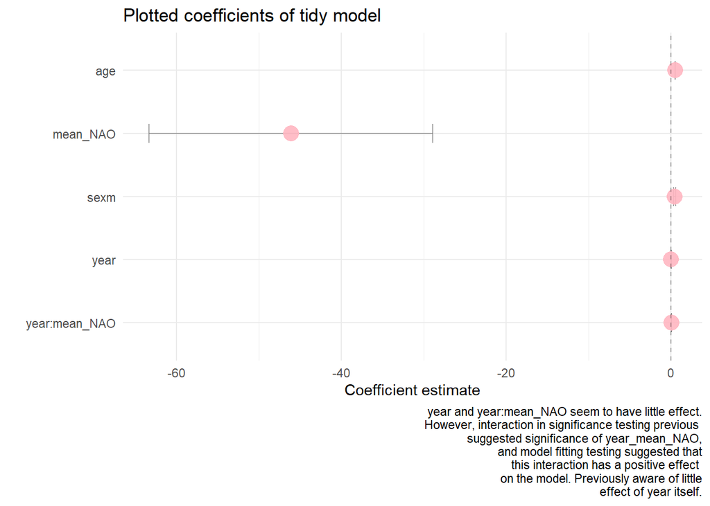

```r
sorted_tidied_model_data <-
  tidy_merge %>%
  filter(effect=="fixed") %>%
  filter(term!="(Intercept)") %>%
  mutate(term=factor(term, levels = rev(term)))

#plot error bars of  estimated coefficients
ggplot(sorted_tidied_model_data, aes(x=estimate.x, y=term)) +
  geom_errorbar(aes(xmin=conf_low, xmax=conf_high),
                width=0.3,
                col="grey50",
                alpha=0.7) +
  geom_point(col="lightpink", size=5, alpha=0.9) +
  geom_vline(xintercept=0, lty="dashed", alpha=0.3) +
  theme_minimal() +
  ylab("") +
  xlab("Coefficient estimate") +
  labs(title = "Plotted coefficients of tidy model",
       caption = "year and year:mean_NAO seem to have little effect.
       However, interaction in significance testing previous
       suggested significance of year_mean_NAO,
       and model fitting testing suggested that
       this interaction has a positive effect
       on the model. Previously aware of little
       effect of year itself.")
```

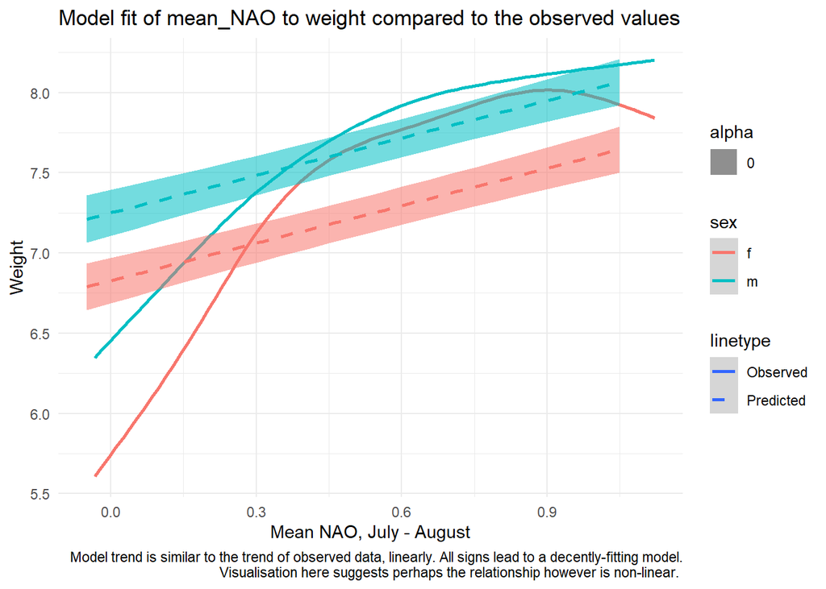

```r
predicted_values <- ggpredict(ID_pop_nosite, terms = c("mean_NAO", "sex")) #predict values using model


#combine predicted values plot and observed values plot to visualise model fit
combined_plot <- ggplot() +
  geom_smooth(data = cleaned_data, aes(x = mean_NAO, y = weight, color = sex, linetype = "Observed"), se = FALSE) +
  geom_smooth(data = predicted_values, aes(x = x, y = predicted, color = group, linetype = "Predicted")) +
  geom_ribbon(data = predicted_values, aes(x = x, ymin = conf.low, ymax = conf.high, fill = group, alpha = 0)) +
  guides(fill = "none") +
  labs(x = "Mean NAO, July - August", y = "Weight") +
  labs(title = "Model fit of mean_NAO to weight compared to the observed values") +
  labs(caption = "Model trend is similar to the trend of observed data, linearly. All signs lead to a decently-fitting model.
       Visualisation here suggests perhaps the relationship however is non-linear. ") +
  scale_linetype_manual( values = c("Observed" = "solid", "Predicted" = "dashed")) +
  theme_minimal()

combined_plot
```

### Conclusion

Comparing our model to our observed values, the model follows the positive trend of the data. The error testing undertaken determined the residuals of the data were normally distributed; our descriptive statistics suggest the selected model was the best fit.

Overall, age, sex, NAO were all significant effectors of Soay sheep weight.